# Chapter 4. 차원 축소(Dimensionality Reduction)

## (줄리아 학습 노트)

### 환경 설정

```julia
print(pwd())
using Pkg
```

```
C:\Users\user
```

```julia
# 모든 패키지가 설치된 후 사용
using UMAP
using Makie
using XLSX
using VegaDatasets
using DataFrames
using MultivariateStats
using RDatasets
using StatsBase
using Statistics
using LinearAlgebra
using Plots
using ScikitLearn
using MLBase
using Distances
```

```julia
C = DataFrame(VegaDatasets.dataset("cars"))
```

|  | Name String | Miles_per_Gallon Float64? | Cylinders Int64 | Displacement Float64 | Horsepower Int64? |
| --- | --- | --- | --- | --- | --- |
| 1 | chevrolet chevelle malibu | 18.0 | 8 | 307.0 | 130 |
| 2 | buick skylark 320 | 15.0 | 8 | 350.0 | 165 |
| 3 | plymouth satellite | 18.0 | 8 | 318.0 | 150 |
| 4 | amc rebel sst | 16.0 | 8 | 304.0 | 150 |
| 5 | ford torino | 17.0 | 8 | 302.0 | 140 |
| 6 | ford galaxie 500 | 15.0 | 8 | 429.0 | 198 |
| 7 | chevrolet impala | 14.0 | 8 | 454.0 | 220 |
| 8 | plymouth fury iii | 14.0 | 8 | 440.0 | 215 |
| 9 | pontiac catalina | 14.0 | 8 | 455.0 | 225 |
| 10 | amc ambassador dpl | 15.0 | 8 | 390.0 | 190 |
| 11 | citroen ds-21 pallas | *missing* | 4 | 133.0 | 115 |
| 12 | chevrolet chevelle concours (sw) | *missing* | 8 | 350.0 | 165 |
| 13 | ford torino (sw) | *missing* | 8 | 351.0 | 153 |
| 14 | plymouth satellite (sw) | *missing* | 8 | 383.0 | 175 |
| 15 | amc rebel sst (sw) | *missing* | 8 | 360.0 | 175 |
| 16 | dodge challenger se | 15.0 | 8 | 383.0 | 170 |
| 17 | plymouth 'cuda 340 | 14.0 | 8 | 340.0 | 160 |
| 18 | ford mustang boss 302 | *missing* | 8 | 302.0 | 140 |
| 19 | chevrolet monte carlo | 15.0 | 8 | 400.0 | 150 |
| 20 | buick estate wagon (sw) | 14.0 | 8 | 455.0 | 225 |
| 21 | toyota corona mark ii | 24.0 | 4 | 113.0 | 95 |
| 22 | plymouth duster | 22.0 | 6 | 198.0 | 95 |
| 23 | amc hornet | 18.0 | 6 | 199.0 | 97 |
| 24 | ford maverick | 21.0 | 6 | 200.0 | 85 |
| 25 | datsun pl510 | 27.0 | 4 | 97.0 | 88 |
| 26 | volkswagen 1131 deluxe sedan | 26.0 | 4 | 97.0 | 46 |
| 27 | peugeot 504 | 25.0 | 4 | 110.0 | 87 |
| 28 | audi 100 ls | 24.0 | 4 | 107.0 | 90 |
| 29 | saab 99e | 25.0 | 4 | 104.0 | 95 |
| 30 | bmw 2002 | 26.0 | 4 | 121.0 | 113 |
| ⋮ | ⋮ | ⋮ | ⋮ | ⋮ | ⋮ |

```julia
typeof(C)
```

```
DataFrame
```

```julia
describe(C)
```

|  | variable Symbol | mean Union… | min Any | median Union… | max Any | nmissing Int64 |
| --- | --- | --- | --- | --- | --- | --- |
| 1 | Name |  | amc ambassador brougham |  | vw rabbit custom | 0 |
| 2 | Miles_per_Gallon | 23.5146 | 9.0 | 23.0 | 46.6 | 8 |
| 3 | Cylinders | 5.47537 | 3 | 4.0 | 8 | 0 |
| 4 | Displacement | 194.78 | 68.0 | 151.0 | 455.0 | 0 |
| 5 | Horsepower | 105.082 | 46 | 95.0 | 230 | 6 |
| 6 | Weight_in_lbs | 2979.41 | 1613 | 2822.5 | 5140 | 0 |
| 7 | Acceleration | 15.5197 | 8.0 | 15.5 | 24.8 | 0 |
| 8 | Year |  | 1970-01-01 |  | 1982-01-01 | 0 |
| 9 | Origin |  | Europe |  | USA | 0 |

### 데이터 전처리

```julia
# 결측치 제거
dropmissing!(C)
```

|  | Name String | Miles_per_Gallon Float64 | Cylinders Int64 | Displacement Float64 | Horsepower Int64 |
| --- | --- | --- | --- | --- | --- |
| 1 | chevrolet chevelle malibu | 18.0 | 8 | 307.0 | 130 |
| 2 | buick skylark 320 | 15.0 | 8 | 350.0 | 165 |
| 3 | plymouth satellite | 18.0 | 8 | 318.0 | 150 |
| 4 | amc rebel sst | 16.0 | 8 | 304.0 | 150 |
| 5 | ford torino | 17.0 | 8 | 302.0 | 140 |
| 6 | ford galaxie 500 | 15.0 | 8 | 429.0 | 198 |
| 7 | chevrolet impala | 14.0 | 8 | 454.0 | 220 |
| 8 | plymouth fury iii | 14.0 | 8 | 440.0 | 215 |
| 9 | pontiac catalina | 14.0 | 8 | 455.0 | 225 |
| 10 | amc ambassador dpl | 15.0 | 8 | 390.0 | 190 |
| 11 | dodge challenger se | 15.0 | 8 | 383.0 | 170 |
| 12 | plymouth 'cuda 340 | 14.0 | 8 | 340.0 | 160 |
| 13 | chevrolet monte carlo | 15.0 | 8 | 400.0 | 150 |
| 14 | buick estate wagon (sw) | 14.0 | 8 | 455.0 | 225 |
| 15 | toyota corona mark ii | 24.0 | 4 | 113.0 | 95 |
| 16 | plymouth duster | 22.0 | 6 | 198.0 | 95 |
| 17 | amc hornet | 18.0 | 6 | 199.0 | 97 |
| 18 | ford maverick | 21.0 | 6 | 200.0 | 85 |
| 19 | datsun pl510 | 27.0 | 4 | 97.0 | 88 |
| 20 | volkswagen 1131 deluxe sedan | 26.0 | 4 | 97.0 | 46 |
| 21 | peugeot 504 | 25.0 | 4 | 110.0 | 87 |
| 22 | audi 100 ls | 24.0 | 4 | 107.0 | 90 |
| 23 | saab 99e | 25.0 | 4 | 104.0 | 95 |
| 24 | bmw 2002 | 26.0 | 4 | 121.0 | 113 |
| 25 | amc gremlin | 21.0 | 6 | 199.0 | 90 |
| 26 | ford f250 | 10.0 | 8 | 360.0 | 215 |
| 27 | chevy c20 | 10.0 | 8 | 307.0 | 200 |
| 28 | dodge d200 | 11.0 | 8 | 318.0 | 210 |
| 29 | hi 1200d | 9.0 | 8 | 304.0 | 193 |
| 30 | datsun pl510 | 27.0 | 4 | 97.0 | 88 |
| ⋮ | ⋮ | ⋮ | ⋮ | ⋮ | ⋮ |

```julia
M = Matrix(C[:, 2:7]);
```

```julia
names(C)
```

```
9-element Vector{String}:
 "Name"
 "Miles_per_Gallon"
 "Cylinders"
 "Displacement"
 "Horsepower"
 "Weight_in_lbs"
 "Acceleration"
 "Year"
 "Origin"
```

```julia
car_origin = C[:, :Origin];
```

```julia
carmap = labelmap(car_origin) # from MLBase
```

```
LabelMap (with 3 labels):
[1] USA
[2] Japan
[3] Europe
```

```julia
uniqueids = labelencode(carmap, car_origin)
```

```
392-element Vector{Int64}:
 1
 1
 1
 1
 1
 1
 1
 1
 1
 1
 1
 1
 1
 ⋮
 1
 1
 1
 1
 2
 1
 1
 1
 3
 1
 1
 1
```

```julia
# center and normalize the data
data = M
data = (data.- mean(data, dims = 1))./std(data, dims = 1)
```

```
392×6 Matrix{Float64}:
 -0.697747   1.48205    1.07591    0.663285   0.619748   -1.28362
 -1.08212    1.48205    1.48683    1.57258    0.842258   -1.46485
 -0.697747   1.48205    1.18103    1.18288    0.539692   -1.64609
 -0.953992   1.48205    1.04725    1.18288    0.53616    -1.28362
 -0.82587    1.48205    1.02813    0.923085   0.554997   -1.82732
 -1.08212    1.48205    2.24177    2.42992    1.60515    -2.00855
 -1.21024    1.48205    2.48068    3.00148    1.62045    -2.37102
 -1.21024    1.48205    2.34689    2.87158    1.57101    -2.55226
 -1.21024    1.48205    2.49023    3.13138    1.70404    -2.00855
 -1.08212    1.48205    1.86908    2.22208    1.02709    -2.55226
 -1.08212    1.48205    1.80219    1.70248    0.689209   -2.00855
 -1.21024    1.48205    1.39127    1.44268    0.743365   -2.73349
 -1.08212    1.48205    1.96464    1.18288    0.922314   -2.18979
  ⋮                                                       ⋮
  0.199113   0.309571  -0.128168   0.143685  -0.0383613   0.311242
  1.86471    0.309571   0.645885  -0.505815   0.0440496   0.528722
  0.327236  -0.862911  -0.367073  -0.323955  -0.462189   -0.377448
 -0.185255   0.309571   0.359199   0.195645  -0.167864   -0.304954
  1.09597   -0.862911  -0.481748  -0.220035  -0.368005   -0.594928
  1.60847   -0.862911  -0.567753  -0.531795  -0.715308   -0.92115
  0.455359  -0.862911  -0.414854  -0.375915  -0.0324748   0.637463
  0.455359  -0.862911  -0.519972  -0.479835  -0.220842    0.0212673
  2.63345   -0.862911  -0.930889  -1.36315   -0.997859    3.28348
  1.09597   -0.862911  -0.567753  -0.531795  -0.803605   -1.4286
  0.583482  -0.862911  -0.711097  -0.661694  -0.415097    1.10867
  0.967851  -0.862911  -0.720653  -0.583754  -0.303253    1.39865
```

PCA 수행을 위해 전치행렬 생성(행<->열 변환)

```julia
# 각각의 차량들이 열이 됨
data'
```

```
6×392 adjoint(::Matrix{Float64}) with eltype Float64:
 -0.697747  -1.08212   -0.697747  …   1.09597    0.583482   0.967851
  1.48205    1.48205    1.48205      -0.862911  -0.862911  -0.862911
  1.07591    1.48683    1.18103      -0.567753  -0.711097  -0.720653
  0.663285   1.57258    1.18288      -0.531795  -0.661694  -0.583754
  0.619748   0.842258   0.539692     -0.803605  -0.415097  -0.303253
 -1.28362   -1.46485   -1.64609   …  -1.4286     1.10867    1.39865
```

> Tall matrix 형태 데이터의 행벡터를 관측치로 사용하는 다른 언어들과 달리 줄리아에서는 wide matrix 형태 데이터의 열벡터를 관측치로 사용하는 경향이 있어, wide matrix 형태로 변환(transpose)해줘야 한다.

## 4.1. PCA

- MultivariateStats.jl 패키지의 PCA 함수 이용
- MultivariateStats.jl 패키지 문서: https://multivariatestatsjl.readthedocs.io/en/stable/pca.html
- `maxoutdim`: 축소 차원 지정 인자

```julia
p = fit(PCA, data', maxoutdim = 2)
```

```
PCA(indim = 6, outdim = 2, principalratio = 0.9194828785333569)
```

- projection matrix 불러오기

```julia
P = projection(p)
```

```
6×2 Matrix{Float64}:
  0.398973  -0.244835
 -0.430615   0.148314
 -0.443531   0.108497
 -0.434122  -0.166158
 -0.430103   0.286095
  0.291926   0.892652
```

- 행별로 변환시키기

```julia
P'*(data[1, :] - mean(p))
```

```
2-element Vector{Float64}:
 -2.3230016965226925
 -0.5713519642644688
```

- transform function(변환 함수) 이용하여 모든 데이터 한꺼번에 변환하기

```julia
Yte = MultivariateStats.transform(p, data')

#notice that Yte[:,1] is the same as P'*(data[1,:]-mean(p))
```

```
2×392 Matrix{Float64}:
 -2.323     -3.20196  -2.66658   -2.60214   …   1.22011  1.70921   1.86951
 -0.571352  -0.68187  -0.992744  -0.621975     -1.87471  0.632857  0.815607
```

```julia
Yte'
```

```
392×2 adjoint(::Matrix{Float64}) with eltype Float64:
 -2.323      -0.571352
 -3.20196    -0.68187
 -2.66658    -0.992744
 -2.60214    -0.621975
 -2.59658    -1.0922
 -4.39584    -1.00949
 -4.91344    -1.36635
 -4.82935    -1.53521
 -4.90421    -1.03943
 -4.05041    -1.66611
 -3.49112    -1.19836
 -3.48212    -1.80003
 -3.49077    -1.18949
  ⋮
  0.0479631   0.226239
  0.67918     0.228058
  0.894187   -0.663259
 -0.468293   -0.222508
  1.10264    -1.04837
  1.53475    -1.52194
  1.10051     0.337723
  1.09338    -0.260354
  3.81463     1.99828
  1.22011    -1.87471
  1.70921     0.632857
  1.86951     0.815607
```

#### recontruct

> reconstruct를 이용하면 근사적으로 원 데이터를 산출할 수 있음

```julia
# reconstruct testing observations(approxiately)
Xr = reconstruct(p, Yte)
```

```
6×392 Matrix{Float64}:
 -0.786928  -1.11055  -0.820834  …   0.945785   0.526984   0.546196
  0.91558    1.27768   1.00103      -0.803445  -0.64215   -0.684075
  0.968334   1.34619   1.075        -0.744559  -0.689425  -0.740696
  1.1034     1.50334   1.32257      -0.218179  -0.847159  -0.947116
  0.835669   1.18209   0.862883     -1.06112   -0.554079  -0.570742
 -1.18816   -1.54341  -1.66462   …  -1.31728    1.06388    1.27381
```

```julia
norm(Xr - data') # 0이 되지 않음
```

```
13.74384105556901
```

PC1과 PC2에 대한 scatter plot 그리기

```julia
Plots.scatter(Yte[1, :], Yte[2, :])
```

[figure not shown]

```julia
Plots.scatter(Yte[1, car_origin .== "USA"],
              Yte[2, car_origin .== "USA"],
              color = 1,
              label = "USA")
Plots.xlabel!("PCA component1")
Plots.ylabel!("PCA component2")
Plots.scatter!(Yte[1, car_origin .== "Japan"],
               Yte[2, car_origin .== "Japan"],
               color = 2,
               label = "Japan")
Plots.scatter!(Yte[1, car_origin .== "Europe"],
               Yte[2, car_origin .== "Europe"],
               color = 3,
               label = "Europe")
```

[figure not shown]

```julia
p = fit(PCA, data', maxoutdim = 3)
```

```
PCA(indim = 6, outdim = 3, principalratio = 0.9625607644667082)
```

```julia
Yte = MultivariateStats.transform(p, data')
```

```
3×392 Matrix{Float64}:
 -2.323     -3.20196   -2.66658   …   1.22011   1.70921    1.86951
 -0.571352  -0.68187   -0.992744     -1.87471   0.632857   0.815607
  0.288803   0.114558   0.287299      0.17119  -0.0208894  0.34713
```

```julia
scatter3d(Yte[1, :], Yte[2, :], Yte[3, :],
          color = uniqueids ,
          legend = false)
```

[figure not shown]

> 자유롭게 회전시키면서 보려고 한다면 Mackie 패키지 이용

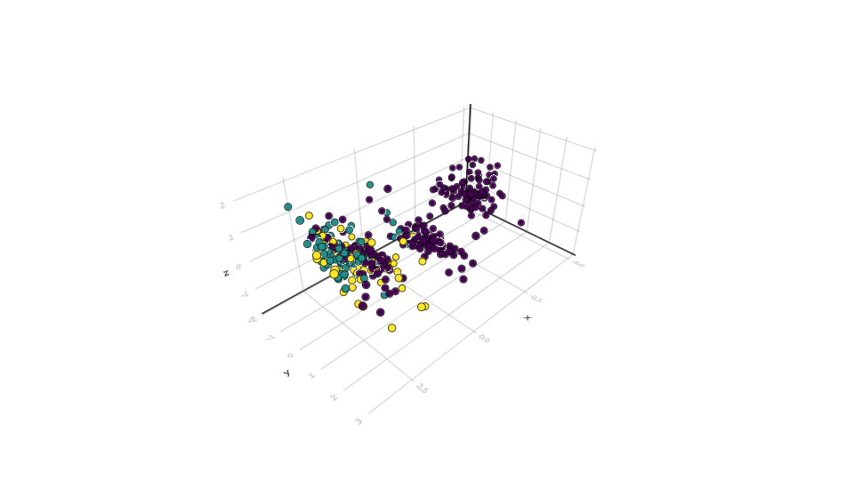

```julia
scene = Makie.scatter(Yte[1, :], Yte[2, :], Yte[3, :],
                      color = uniqueids,
                      markersize = 100)
```

```julia
# display(scene)
```

```julia
?Makie.scatter
```

```
scatter(positions)
scatter(x, y)
scatter(x, y, z)
```

Plots a marker for each element in `(x, y, z)`, `(x, y)`, or `positions`.

Attributes

Available attributes and their defaults for `Scatter{T} where T` are:

```
  ambient           Float32[0.55, 0.55, 0.55]
  color             :gray65
  colormap          :viridis
  diffuse           Float32[0.4, 0.4, 0.4]
  distancefield     "nothing"
  glowcolor         RGBA{N0f8}(0.0,0.0,0.0,0.0)
  glowwidth         0.0
  lightposition     :eyeposition
  linewidth         1
  marker            Circle{T} where T
  marker_offset     AbstractPlotting.Automatic()
  markersize        10
  markerspace       Pixel
  nan_color         RGBA{Float32}(0.0f0,0.0f0,0.0f0,0.0f0)
  overdraw          false
  rotations         Billboard()
  shininess         32.0f0
  specular          Float32[0.2, 0.2, 0.2]
  ssao              false
  strokecolor       :black
  strokewidth       1.0
  transform_marker  false
  transparency      false
  uv_offset_width   Float32[0.0, 0.0, 0.0, 0.0]
  visible           true
```

```julia
?display
```

```
search: display displaysize displayable redisplay popdisplay pushdisplay
```

```
display(x)
display(d::AbstractDisplay, x)
display(mime, x)
display(d::AbstractDisplay, mime, x)
```

AbstractDisplay `x` using the topmost applicable display in the display stack, typically using the richest supported multimedia output for `x`, with plain-text `stdout` output as a fallback. The `display(d, x)` variant attempts to display `x` on the given display `d` only, throwing a `MethodError` if `d` cannot display objects of this type.

In general, you cannot assume that `display` output goes to `stdout` (unlike `print(x)` or `show(x)`). For example, `display(x)` may open up a separate window with an image. `display(x)` means "show `x` in the best way you can for the current output device(s)." If you want REPL-like text output that is guaranteed to go to `stdout`, use `show(stdout, "text/plain", x)` instead.

There are also two variants with a `mime` argument (a MIME type string, such as `"image/png"`), which attempt to display `x` using the requested MIME type *only*, throwing a `MethodError` if this type is not supported by either the display(s) or by `x`. With these variants, one can also supply the "raw" data in the requested MIME type by passing `x::AbstractString` (for MIME types with text-based storage, such as text/html or application/postscript) or `x::Vector{UInt8}` (for binary MIME types).

To customize how instances of a type are displayed, overload `show` rather than `display`, as explained in the manual section on custom pretty-printing.

### 2. t-SNE

- t-분포 확률적 임베딩
- 줄리아에서 t-SNE를 수행하는 여러가지 방법 소개: https://github.com/nassarhuda/JuliaTutorials/blob/master/TSNE/TSNE.ipynb
- 여기서는 싸이킷런을 이용함

```julia
@sk_import manifold : TSNE
```

```
PyObject <class 'sklearn.manifold._t_sne.TSNE'>
```

```julia
tfn = TSNE(n_components = 2) # perplexity=20.0,early_exaggeration=50
```

```
PyObject TSNE()
```

```julia
Y2 = tfn.fit_transform(data);
```

```julia
Plots.scatter(Y2[:, 1], Y2[:, 2],
              color = uniqueids,
              legend = false,
              size = (400, 300), markersize = 3)
```

[figure not shown]

### 3. UMAP

> Uniform Manifold Approximation and Projection for Dimension Reduction

> UMAP 문서: https://umap-learn.readthedocs.io/en/latest/index.html
- UMAP의 원리는 좀 더 수학적인 이해를 필요로 하며, 추후 보완 필요
- umap.jl GitHub: https://github.com/dillondaudert/UMAP.jl
- 관련 블로그 포스팅: https://data.korea.ac.kr/?p=4727 / https://data-newbie.tistory.com/169

```julia
# cars를 normalization한 데이터
L = cor(data, data, dims = 2)
```

```
392×392 Matrix{Float64}:
  1.0        0.960859   0.980739   …  -0.15566    -0.985626  -0.987866
  0.960859   1.0        0.98143       -0.214363   -0.987499  -0.991891
  0.980739   0.98143    1.0           -0.0696836  -0.996246  -0.991744
  0.976964   0.990698   0.987283      -0.221491   -0.988356  -0.992669
  0.990434   0.972891   0.996659      -0.0743694  -0.996455  -0.991605
  0.914253   0.980862   0.953547   …  -0.131122   -0.964837  -0.963207
  0.889778   0.97211    0.943482      -0.103086   -0.950894  -0.947428
  0.898549   0.97346    0.950816      -0.0822493  -0.957647  -0.952454
  0.875422   0.969313   0.930575      -0.147112   -0.939694  -0.938767
  0.930558   0.981423   0.9771        -0.0440158  -0.978168  -0.971042
  0.955677   0.992142   0.986872   …  -0.108384   -0.986813  -0.986542
  0.967174   0.981264   0.99359       -0.0370968  -0.994966  -0.987287
  0.972225   0.976286   0.978719      -0.0923206  -0.986185  -0.986353
  ⋮                                ⋱               ⋮
 -0.404013  -0.466732  -0.411041   …  -0.0706252   0.453477   0.453808
 -0.478238  -0.638193  -0.507226       0.704189    0.538071   0.564949
 -0.622301  -0.58335   -0.521844       0.811384    0.550078   0.593987
  0.864173   0.861265   0.885541      -0.0825738  -0.857301  -0.867163
 -0.468406  -0.480296  -0.373361       0.933309    0.407542   0.465312
 -0.389497  -0.452262  -0.315133   …   0.96802     0.358235   0.415197
 -0.968423  -0.931524  -0.958152       0.201446    0.947663   0.953556
 -0.863386  -0.861127  -0.826112       0.562914    0.830458   0.861035
 -0.933058  -0.982261  -0.952714       0.214646    0.971      0.971526
 -0.15566   -0.214363  -0.0696836      1.0         0.114222   0.175466
 -0.985626  -0.987499  -0.996246   …   0.114222    1.0        0.997582
 -0.987866  -0.991891  -0.991744       0.175466    0.997582   1.0
```

```julia
embedding = umap(L, 2)
```

```
2×392 Matrix{Float64}:
 5.07002  5.45536  4.73657  5.1546   4.77693  …  -3.72207  -7.64067  -7.75562
 4.78205  5.20044  5.25438  4.78085  5.17916      4.40639  -1.9965   -1.81007
```

```julia
Plots.scatter(embedding[1, :], embedding[2, :], color = uniqueids)
```

[figure not shown]

For UMAP, we can create distances between every pair of observations differently, if we choose to. But even with both choices, we will see that UMAP generates a very similar pattern to what we have observed with t-SNE and PCA.

```julia
L = pairwise(Euclidean(), data, data, dims = 1)
```

```
392×392 Matrix{Float64}:
 4.21468e-8  1.10715   0.647168  0.58605   …  3.85916   4.3455    4.59372
 1.10715     0.0       0.719382  0.698612     4.64789   5.12834   5.36058
 0.647168    0.719382  0.0       0.463634     4.07019   4.7564    4.99914
 0.58605     0.698612  0.463634  0.0          4.13105   4.58092   4.83094
 0.621288    0.954891  0.374659  0.616639     3.98254   4.75213   5.01882
 2.47478     1.47736   2.02351   2.16025   …  5.74861   6.35209   6.54297
 3.14437     2.11486   2.63678   2.79031      6.27365   6.96953   7.15936
 3.04449     2.03888   2.52157   2.69941      6.14792   6.92088   7.12142
 3.17107     2.11928   2.69451   2.79893      6.34131   6.89638   7.07059
 2.23206     1.33588   1.66126   1.90321      5.32719   6.22325   6.45446
 1.51179     0.659817  0.978414  1.18545   …  4.83905   5.57813   5.82124
 1.75698     1.28905   1.26423   1.54809      4.75916   5.80249   6.08108
 1.45611     0.955045  1.09718   1.35214      4.81189   5.61281   5.86617
 ⋮                                         ⋱            ⋮
 2.62213     3.40532   3.02296   2.83541   …  2.53796   1.81348   2.02447
 3.62058     4.43812   4.0068    3.98238      2.82647   2.33005   2.22035
 3.40559     4.17169   3.71885   3.63718      1.37693   1.58393   1.94491
 1.98692     2.7771    2.36362   2.20616      2.46403   2.43016   2.72002
 3.65688     4.4219    3.9215    3.9114       0.994663  1.84791   2.04556
 4.10623     4.91014   4.3493    4.39442   …  0.726605  2.30181   2.44698
 3.77449     4.52334   4.165     4.00832      2.3068    0.744501  1.02571
 3.6182      4.40921   3.98058   3.87062      1.6903    1.14289   1.48919
 6.94294     7.72663   7.36226   7.2094       5.04265   3.13243   2.73147
 3.85916     4.64789   4.07019   4.13105      0.0       2.62465   2.87857
 4.3455      5.12834   4.7564    4.58092   …  2.62465   0.0       0.500499
 4.59372     5.36058   4.99914   4.83094      2.87857   0.500499  0.0
```

```julia
embedding = umap(-L, 2)
```

```
2×392 Matrix{Float64}:
 8.54793  10.8333   9.33249  9.24227  …  -6.33792  -4.15378  -4.37412
 3.24522   1.18145  3.20328  3.16806     -3.4841   -1.10661  -0.913583
```

```julia
Plots.scatter(embedding[1, :], embedding[2, :], color = uniqueids)
```

[figure not shown]

# Finally...

After finishing this notebook, you should be able to:

- [ ] apply tsne on your data
- [ ] apply umap on your data
- [ ] apply pca on your data
- [ ] generate a 3d plot
- [ ] call a function from Python's ScikitLearn

## 번외

### 줄리아 패키지를 이용한 TSne 수행

```julia
using TSne
```

```julia
# Pkg.add("TSne")
```

```julia
# Pkg.add("MLDatasets")
```

```julia
using Statistics,
    MLDatasets,
    BenchmarkTools,
    Plots,
    RDatasets,
    LinearAlgebra,
    PyCall,
    ScikitLearn,
    ColorSchemes
```

```julia
#Pkg.add("ColorSchemes")
```

```julia
# my plotting function for producing visually appealing plots
function my_tsne_plot(Y, d, labels)
    colorsvec = get(ColorSchemes.tab10, labels, :extrema)
    Plots.plot(legend = false, asxis = false, grid = false)
    tsneplot = Plots.scatter!(Y[:, 1], Y[:, 2],
                        marker = (2, 2, :auto, stroke(0)), alpha = 0.8,
                        background_color =:black,
                        color = colorsvec)
    for i = 0:9
        mx, my = mean(Y[findall(labels.==i), :], dims = 1)
        s = Shape(mx.+[-d, d, d, -d], my.+[-d, -d, d, d])
        Plots.plot!(s,
                    color = ColorSchemes.tab10[i+1],
                    linewidth = 0, alpha = 0.9)
        annotate!(mx, my, Plots.text(string(i), color =:white))
    end
    return tsneplot
end
```

```
my_tsne_plot (generic function with 1 method)
```

```julia
alldata, labels = MNIST.traindata(Float64);
```

```julia
data = reshape(permutedims(alldata[:, :, 1:3000], (3, 1, 2)),
               3000, size(alldata, 1)*size(alldata, 2));
labels = labels[1:3000]
```

```
3000-element Vector{Int64}:
 5
 0
 4
 1
 9
 2
 1
 3
 1
 4
 3
 5
 3
 ⋮
 1
 9
 4
 8
 6
 5
 1
 7
 0
 9
 1
 5
```

```julia
@show size(data);
```

```
size(data) = (3000, 784)
```

#### Julia package 이용

```julia
using TSne
```

```julia
rescale(A; dims = 1) = (A .- mean(A, dims = dims)) ./ max.(std(A, dims = dims),
        eps())
```

```
rescale (generic function with 1 method)
```

```julia
X = rescale(data, dims = 1);
```

```julia
Y1 = tsne(X, 2, 50, 1000, 20.0);
```

[output not shown]

[output cut: 464 more lines]

[output not shown]

```julia
my_tsne_plot(Y1, 5, labels)
```

[figure not shown]

### ScikitLearn 결과와 비교

```julia
@sk_import manifold : TSNE
tfn = TSNE(n_components=2,perplexity=20.0,early_exaggeration=50)
```

```
WARNING: redefinition of constant TSNE. This may fail, cause incorrect answers, or produce other errors.
```

```
PyObject TSNE(early_exaggeration=50, perplexity=20.0)
```

```julia
Y2 = tfn.fit_transform(data);
```

```julia
my_tsne_plot(Y2, 4, labels)
```

[figure not shown]